# Final Response to the Assignment

Komla

2025-02-27

# Introduction

This document presents the analysis of the dataset contained in the Excel file **stats_R_Python_questions_2.xlsx**. The assignment consists of three main parts:

1. **Summary Statistics and Plotting:**  
   Compute the mean and standard deviation of the digital counts and plot these values (Mean ± SD) over time for each marker and treatment group.
2. **T-Test Comparisons (DAY1 vs. DAY8):**  
   Test whether DAY8 and DAY1 significantly differ at α = 0.05 under each treatment for each marker. A paired t-test is used when the same subjects are measured at both time points; otherwise, an unpaired t-test is applied.
3. **Mixed-Effects Modeling, Residual Analysis, and Post Hoc Comparisons:**  
   Assess the constant variance assumption via a residuals vs. fitted plot, fit mixed-effects models for each marker, and report both the unadjusted and Bonferroni-adjusted p-values for the DAY22 vs. DAY8 contrast.

Below, each step is described with the corresponding code.

# 1. Summary Statistics and Plotting

## 1.a) Compute Mean and Standard Deviation

```r
# Load necessary libraries
library(readxl)
library(tidyverse)
library(ggplot2)
library(lme4)
library(lmerTest)
library(broom)
library(broom.mixed)
library(emmeans)
library(knitr)  # for kable()

# Set the working directory (adjust this )
setwd("/Users/komlagnona/Desktop/MYDESK/MYWORK")

# Define file path (adjust this)
file_path <- "/Users/komlagnona/Desktop/MYDESK/MYWORK/stats_R_Python_questions_2.xlsx"

# Load the "data" sheet
data <- read_excel(file_path, sheet = "data")

# Check data structure and summary statistics
str(data)
```

```
## tibble [254 × 5] (S3: tbl_df/tbl/data.frame)
##  $ sbj_id       : chr [1:254] "A" "A" "A" "B" ...
##  $ sample_time  : chr [1:254] "DAY1" "DAY1" "DAY1" "DAY1" ...
##  $ digital_count: num [1:254] 169 207 10 636 821 ...
##  $ marker       : chr [1:254] "C4" "C8" "TG" "C4" ...
##  $ trt_group    : chr [1:254] "TA" "TA" "TA" "TA" ...
```

```r
summary(data)
```

```
##     sbj_id          sample_time        digital_count       marker
##  Length:254         Length:254         Min.   :   4.0   Length:254
##  Class :character   Class :character   1st Qu.: 100.5   Class :character
##  Mode  :character   Mode  :character   Median : 292.0   Mode  :character
##                                        Mean   : 569.4
##                                        3rd Qu.: 572.5
##                                        Max.   :6711.0
##   trt_group
##  Length:254
##  Class :character
##  Mode  :character
##
##
##
```

```r
# Compute mean and standard deviation for digital_count by marker, sample_time, and trt_group
summary_stats <- data %>%
  group_by(marker, sample_time, trt_group) %>%
  summarise(
    mean_digital_count = mean(digital_count, na.rm = TRUE),
    sd_digital_count = sd(digital_count, na.rm = TRUE),
    .groups = "drop"
  ) %>%
  as.data.frame()

# View the results in a nicely formatted table
knitr::kable(summary_stats, caption = "Summary Statistics: Mean and SD by Marker, Sample Time, and Treatment Group")
```

Summary Statistics: Mean and SD by Marker, Sample Time, and Treatment Group

| marker | sample_time | trt_group | mean_digital_count | sd_digital_count |
| --- | --- | --- | --- | --- |
| C4 | DAY1 | TA | 452.71429 | 442.32104 |
| C4 | DAY1 | TB | 762.00000 | 913.05558 |
| C4 | DAY1 | TC | 383.42857 | 199.72302 |
| C4 | DAY15 | TA | 764.60000 | 791.18348 |
| C4 | DAY15 | TB | 614.83333 | 649.82903 |
| C4 | DAY15 | TC | 449.16667 | 297.92309 |
| C4 | DAY22 | TA | 715.25000 | 173.11918 |
| C4 | DAY22 | TB | 648.83333 | 737.52652 |
| C4 | DAY22 | TC | 318.66667 | 169.04043 |
| C4 | DAY29 | TA | 381.60000 | 272.95293 |
| C4 | DAY29 | TB | 485.60000 | 410.41114 |
| C4 | DAY29 | TC | 350.40000 | 213.80084 |
| C4 | DAY8 | TA | 869.85714 | 553.87737 |
| C4 | DAY8 | TB | 1200.14286 | 1096.27999 |
| C4 | DAY8 | TC | 335.75000 | 90.42631 |
| C8 | DAY1 | TA | 537.42857 | 502.53353 |
| C8 | DAY1 | TB | 1781.00000 | 2638.12594 |
| C8 | DAY1 | TC | 618.28571 | 681.95521 |
| C8 | DAY15 | TA | 588.20000 | 532.56427 |
| C8 | DAY15 | TB | 1617.83333 | 1864.98508 |
| C8 | DAY15 | TC | 643.66667 | 522.70093 |
| C8 | DAY22 | TA | 585.50000 | 130.71215 |
| C8 | DAY22 | TB | 1646.33333 | 1859.06156 |
| C8 | DAY22 | TC | 499.83333 | 283.75441 |
| C8 | DAY29 | TA | 491.80000 | 484.79243 |
| C8 | DAY29 | TB | 1041.80000 | 1215.09802 |
| C8 | DAY29 | TC | 416.60000 | 219.29957 |
| C8 | DAY8 | TA | 984.28571 | 1005.96185 |
| C8 | DAY8 | TB | 2471.42857 | 2827.26492 |
| C8 | DAY8 | TC | 650.00000 | 404.59939 |
| TG | DAY1 | TA | 21.00000 | 13.08434 |
| TG | DAY1 | TB | 48.20000 | 51.21230 |
| TG | DAY1 | TC | 29.42857 | 15.28460 |
| TG | DAY15 | TA | 106.40000 | 89.41644 |
| TG | DAY15 | TB | 65.00000 | 50.82519 |
| TG | DAY15 | TC | 155.50000 | 153.75533 |
| TG | DAY22 | TA | 156.00000 | 92.63189 |
| TG | DAY22 | TB | 131.50000 | 86.81417 |
| TG | DAY22 | TC | 100.66667 | 88.70551 |
| TG | DAY29 | TA | 58.60000 | 41.15580 |
| TG | DAY29 | TB | 63.00000 | 44.28318 |
| TG | DAY29 | TC | 75.40000 | 20.23116 |
| TG | DAY8 | TA | 227.42857 | 251.52923 |
| TG | DAY8 | TB | 231.57143 | 216.45081 |
| TG | DAY8 | TC | 62.50000 | 34.66506 |

# 1.b) Plot Mean ± SD Over Time for Each Marker and Treatment

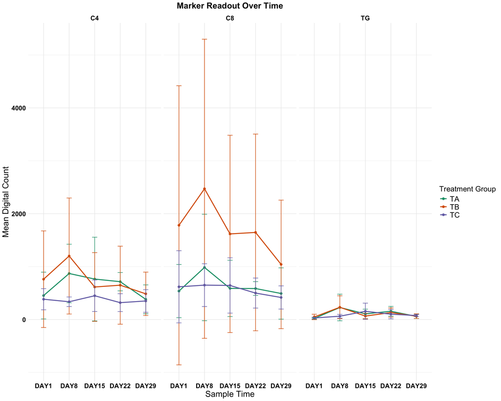

```r
# Convert sample_time to an ordered factor before plotting
summary_stats <- summary_stats %>%
  mutate(sample_time = factor(sample_time, levels = c("DAY1", "DAY8", "DAY15", "DAY22", "DAY29")))

# Create the plot using ggplot2
summary_plots <- ggplot(summary_stats, aes(x = sample_time, y = mean_digital_count,
                                            color = trt_group, group = trt_group)) +
  geom_line(linewidth = 1) +
  geom_point(size = 2) +
  geom_errorbar(aes(ymin = mean_digital_count - sd_digital_count,
                    ymax = mean_digital_count + sd_digital_count), width = 0.2) +
  facet_wrap(~ marker, scales = "fixed") +
  labs(title = "Marker Readout Over Time",
       x = "Sample Time",
       y = "Mean Digital Count",
       color = "Treatment Group") +
  scale_color_brewer(palette = "Dark2") +
  theme_minimal() +
  theme(
    plot.title = element_text(size = 18, face = "bold", hjust = 0.5, color = "black"), # Centered title
    axis.title.x = element_text(size = 18, color = "black"),  # X-axis label
    axis.title.y = element_text(size = 18, color = "black"),  # Y-axis label
    axis.text.x = element_text(size = 14, face = "bold",color = "black"),   # X-axis tick labels
    axis.text.y = element_text(size = 14, face = "bold",color = "black"),   # Y-axis tick labels
    legend.title = element_text(size = 16, color = "black"),  # Legend title
    legend.text = element_text(size = 16, color = "black"),   # Legend text
    strip.text = element_text(size = 14, face = "bold", color = "black")  # Facet titles
  )

# View the plot
print(summary_plots)
```

#2. T-Test Comparisons (DAY1 vs. DAY8)

Let’s test whether DAY8 and DAY1 significantly differ under each treatment for each marker. I will use a paired t-test if the same subjects are measured at both time points, and an unpaired t-test otherwise.

```r
# Filter data for DAY1 and DAY8 only
day1_day8_data <- data %>%
  filter(sample_time %in% c("DAY1", "DAY8"))

# Perform t-tests for each marker and treatment group
t_test_results <- day1_day8_data %>%
  group_by(marker, trt_group) %>%
  summarise(
    test = list({
      df <- pick(everything())
      # Identify unique subject IDs for each day
      subs_day1 <- unique(df$sbj_id[df$sample_time == "DAY1"])
      subs_day8 <- unique(df$sbj_id[df$sample_time == "DAY8"])

      # Check if the same subjects are present (after sorting)
      if (length(subs_day1) == length(subs_day8) && all(sort(subs_day1) == sort(subs_day8))) {
        # For paired t-test: sort by subject ID to ensure proper pairing
        x_vals <- df %>%
          filter(sample_time == "DAY1") %>%
          arrange(sbj_id) %>%
          pull(digital_count)
        y_vals <- df %>%
          filter(sample_time == "DAY8") %>%
          arrange(sbj_id) %>%
          pull(digital_count)

        t.test(x = x_vals, y = y_vals, paired = TRUE)
      } else {
        # Otherwise, use an unpaired t-test
        x_vals <- df %>% filter(sample_time == "DAY1") %>% pull(digital_count)
        y_vals <- df %>% filter(sample_time == "DAY8") %>% pull(digital_count)

        t.test(x = x_vals, y = y_vals, paired = FALSE)
      }
    }),
    .groups = "drop"
  ) %>%
  mutate(
    results = map(test, tidy)
  ) %>%
  unnest(results) %>%
  select(marker, trt_group, p.value, estimate, statistic)

# View the t-test results in a nicely formatted table
knitr::kable(t_test_results, caption = "T-Test Results (DAY1 vs. DAY8) by Marker and Treatment Group")
```

T-Test Results (DAY1 vs. DAY8) by Marker and Treatment Group

| marker | trt_group | p.value | estimate | statistic |
| --- | --- | --- | --- | --- |
| C4 | TA | 0.0312945 | -417.14286 | -2.7968271 |
| C4 | TB | 0.4693234 | -438.14286 | -0.7531563 |
| C4 | TC | 0.6013570 | 47.67857 | 0.5418475 |
| C8 | TA | 0.1213232 | -446.85714 | -1.8037349 |
| C8 | TB | 0.6745258 | -690.42857 | -0.4337380 |
| C8 | TC | 0.9250361 | -31.71429 | -0.0967895 |
| TG | TA | 0.0729864 | -206.42857 | -2.1679333 |
| TG | TB | 0.0682489 | -183.37143 | -2.1584265 |
| TG | TC | 0.1507046 | -33.07143 | -1.8101550 |

```r
# Select only significant results (p < 0.05)
significant_t_test_results <- filter(t_test_results, p.value < 0.05)
selected_markers           <- significant_t_test_results$marker
selected_trt_group         <- significant_t_test_results$trt_group

# Print summary statement for significant markers
cat("DAY1 and DAY8 differ for the following marker(s):",
    selected_markers, "in the treatment group(s):", selected_trt_group, "\n")
```

```
## DAY1 and DAY8 differ for the following marker(s): C4 in the treatment group(s): TA
```

*Summary.*

- The difference in treatments between DAY8 and DAY1 is significantly different (P < 0.05) for marker C4 under treatment TA. Note: the evidence is suggestive (p < 0.1) for marker TG under treatments TA and TB

#3. Mixed-Effects Modeling, Residual Analysis, and Post Hoc Comparisons

## 3.a) Residuals vs. Fitted Plot

First, let’s assess any departure from the assumptions unlying the tukey test. We already knowthe experimental units are randomly drawn from a population. That said, let’s check for the constant variance (homoscedasticity) assumption by plotting the residuals versus the fitted values for each marker.

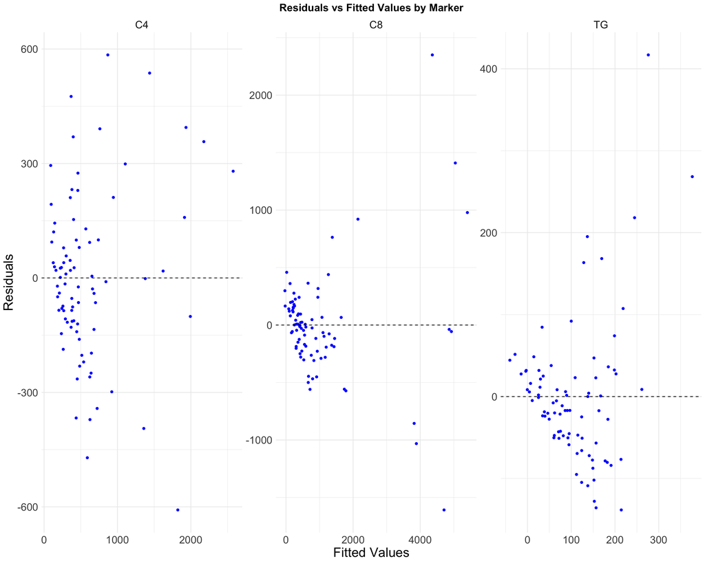

```r
# Function to fit the model and append residuals and fitted values for a given marker
analyze_marker_resid <- function(df) {
  model <- lmer(digital_count ~ sample_time + trt_group + (1 | sbj_id), data = df)
  df %>% mutate(fitted = fitted(model), residuals = resid(model))
}

# Apply the function to each marker and combine the results
resid_data <- data %>%
  group_by(marker) %>%
  group_modify(~ analyze_marker_resid(.x)) %>%
  ungroup()

# Create the Residuals vs. Fitted plot for all markers
p <- ggplot(resid_data, aes(x = fitted, y = residuals)) +
  geom_point(color = "blue") +
  geom_hline(yintercept = 0, color = "black", linetype = "dashed") +
  facet_wrap(~ marker, scales = "free") +
  labs(title = "Residuals vs Fitted Values by Marker",
       x = "Fitted Values",
       y = "Residuals") +
  theme_minimal()

#
p<- p + theme(text = element_text(size = 20), plot.title = element_text(size = 16, face = "bold", hjust = 0.5, color = "black"))
# Visualize the plot
print(p)
```

## 3.b) Mixed-Effects Model with Post Hoc Comparisons

Here, i fit a mixed-effects model for each marker, extract the treatment effect p-values, and perform pairwise comparisons for the contrast between DAY22 and DAY8. Both unadjusted and Bonferroni-adjusted p-values are reported.

```r
marker_results <- data %>%
  group_by(marker) %>%
  nest() %>%
  mutate(
    # Fit the model for each marker
    model = map(data, ~ lmer(digital_count ~ sample_time + trt_group + (1 | sbj_id), data = .x)),

    # Extract the ANOVA table and get the p-value for the treatment effect
    anova_out = map(model, ~ anova(.x)),
    trt_p_value = map_dbl(anova_out, ~ .x["trt_group", "Pr(>F)"]),

    # Compute estimated marginal means for sample_time
    emms = map(model, ~ emmeans(.x, ~ sample_time)),

    # Get unadjusted pairwise comparisons among sample_time levels
    pairwise_unadj = map(emms, ~ contrast(.x, method = "pairwise", adjust = "none")),

    # Get Bonferroni-adjusted pairwise comparisons among sample_time levels
    pairwise_bonf = map(emms, ~ contrast(.x, method = "pairwise", adjust = "bonferroni")),

    # Extract the unadjusted p-value for the contrast between DAY22 and DAY8
    day22_day8_p_unadj = map_dbl(pairwise_unadj, ~ {
      tmp <- as.data.frame(.x) %>% filter(contrast %in% c("DAY22 - DAY8", "DAY8 - DAY22"))
      if(nrow(tmp) > 0) tmp$p.value[1] else NA_real_
    }),

    # Extract the Bonferroni-adjusted p-value for the contrast between DAY22 and DAY8
    day22_day8_p_bonf = map_dbl(pairwise_bonf, ~ {
      tmp <- as.data.frame(.x) %>% filter(contrast %in% c("DAY22 - DAY8", "DAY8 - DAY22")) #making sure the proper test is extracted. DAY 22-DAY8 is equivalent of DAY8 - DAY22
      if(nrow(tmp) > 0) tmp$p.value[1] else NA_real_
    })
  ) %>%
  select(marker, trt_p_value, day22_day8_p_unadj, day22_day8_p_bonf)

# View the mixed model results in a nicely formatted table
knitr::kable(marker_results, caption = "Mixed-Effects Model Results with Unadjusted and Bonferroni-adjusted p-values")
```

Mixed-Effects Model Results with Unadjusted and Bonferroni-adjusted p-values

| marker | trt_p_value | day22_day8_p_unadj | day22_day8_p_bonf |
| --- | --- | --- | --- |
| C4 | 0.2406997 | 0.0055407 | 0.0554073 |
| C8 | 0.1502659 | 0.0075996 | 0.0759965 |
| TG | 0.7247242 | 0.0768486 | 0.7684857 |

*Summary.*

Here, I report the unadjusted and adjusted p-values. I opted to use Bonferroni correction to adjust for multiple testing and to control for the family wise error rate.

- The p-values for the treatment effect of all markers are > 0.05. In other words, there is not enough statistical evidence to conclude that the treatment (trt_group) has an effect on the marker digital_count at the 5% significance level
- Aslo, we do not have enough evidence to conclude that the difference in digital_count between DAY22 and DAY8 for all markers is significant (p > 0.05).
- Note: the evidence is suggestive (p-val < 0.1) for markers C4 & C8